# mstate2

Second-order Markov multistate models in R

Josu Najera-Zuloaga · João Carmezim · Mireia Besalú · Cristian Tebé · Guadalupe Gómez Melis

jcarmezim@igtp.cat

October 21, 2026

[figure not shown]

[figure not shown]

## DIVINE through first-order eyes

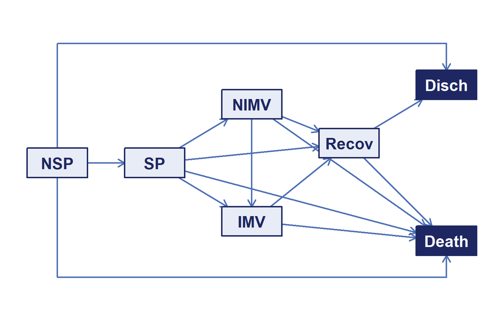

**DIVINE**: 2076 patients hospitalised with COVID-19, followed daily. `NSP`/`SP` non-severe/severe pneumonia · `NIMV`/`IMV` non-invasive/invasive ventilation · `Recov` recovery · `Disch` · `Death`.

First-order probabilities for a patient in `SP` **today**:

| tomorrow | probability |
| --- | --- |
| SP | 0.831 |
| Recov | 0.072 |
| NIMV | 0.052 |
| IMV | 0.036 |
| Death | 0.008 |

Under first order, every patient in `SP` today has probability **0.052** of non-invasive ventilation tomorrow, whatever happened before.

## What we already do: first-order models

$$P\big(X_s = \ell \mid X_{s-1} = j,\; X_{s-2},\; \dots\big) \;=\; P\big(X_s = \ell \mid X_{s-1} = j\big) \;=\; P_{j\ell}$$

The future depends on the past **only through the current state**.

**Continuous time** (`mstate`)

One hazard per transition, Cox models, Aalen–Johansen probabilities.

```r
msd <- msprep(time, status, data, tmat)
cx  <- coxph(Surv(Tstart, Tstop, status) ~
               strata(trans), data = msd)
pt  <- probtrans(msfit(cx, trans = tmat), 0)
```

**Discrete time** (days)

One transition matrix, estimated by pooled counts; predictions by matrix powers:

$$\hat P_{j\ell} = \frac{\sum_s N_{j\ell}(s)}{\sum_s Y_{j}(s-1)},
\qquad
\mathbf P(n) = \mathbf P^{\,n}$$

## Example: first order, step by step

**1. One row**: patients in `SP` today

| tomorrow | moves N | at risk Y | P = N / Y |
| --- | --- | --- | --- |
| SP | 2560 | 3079 | 0.831 |
| Recov | 223 | 3079 | 0.072 |
| NIMV | 160 | 3079 | 0.052 |
| IMV | 111 | 3079 | 0.036 |
| Death | 25 | 3079 | 0.008 |

$\hat P_{j\ell} = \dfrac{\sum_s N_{j\ell}(s)}{\sum_s Y_j(s-1)}$: moves from $j$ to $\ell$ over patient-days at risk in $j$, all days pooled.

**2. Every row: the matrix $\hat{\mathbf P}$** (rows = today, columns = tomorrow; blank = impossible; each row sums to 1)

|  | NSP | SP | Recov | NIMV | IMV | Disch | Death |
| --- | --- | --- | --- | --- | --- | --- | --- |
| NSP | 0.843 | 0.024 |  |  |  | 0.129 | 0.003 |
| SP |  | 0.831 | 0.072 | 0.052 | 0.036 |  | 0.008 |
| Recov |  |  | 0.890 |  |  | 0.107 | 0.003 |
| NIMV |  |  | 0.099 | 0.790 | 0.100 |  | 0.011 |
| IMV |  |  | 0.030 |  | 0.943 |  | 0.027 |
| Disch |  |  |  |  |  | 1.000 |  |
| Death |  |  |  |  |  |  | 1.000 |

**3. Chapman–Kolmogorov.** In `SP` today, probability of `NIMV` in **2 days**: sum over every possible state $k$ tomorrow, $P^{(2)}_{\text{SP},\text{NIMV}} = \sum_k P_{\text{SP},k}\,P_{k,\text{NIMV}}$ = 0.831 × 0.052 (SP → SP → NIMV) + 0.052 × 0.790 (SP → NIMV → NIMV) = **0.084**. In matrix form, $\mathbf P(2) = \mathbf P \cdot \mathbf P$ and $\mathbf P(n) = \mathbf P^{\,n}$.

## Is the present enough?

**Patient A**: yesterday `NSP`, today `SP`

*has just worsened to severe pneumonia*

**Patient B**: yesterday `SP`, today `SP`

*has had severe pneumonia for some days*

|  | First order | From the data, by yesterday’s state |
| --- | --- | --- |
| P(`NIMV` tomorrow), patient A | 5.2% | **22.4%** (18.4%–26.4%) |
| P(`NIMV` tomorrow), patient B | 5.2% | **2.5%** (2.0%–3.1%) |

## Ways to let the past matter

| Approach | Memory added | In practice |
| --- | --- | --- |
| Semi-Markov (clock reset) | time already spent in the current state | continuous time; does not use the previous state |
| Expanding the state space | e.g. “`SP`, first day” and “`SP`, later days” | chosen by hand, state by state |
| Previous state as a covariate | the previous state, in each transition’s hazard model | transition by transition; multi-step prediction needs extra modelling |
| **Second-order Markov chain** | **the state at the previous time, for every state** | **systematic; still a Markov chain (on pairs of states)** |

The second-order model is the smallest step beyond first order that

1. lets the previous state change **every** transition probability,
2. keeps the counting-process estimators and the Chapman–Kolmogorov predictions of the first-order model, and
3. contains the first-order model as a **special case**.

## Second-order Markov models

$$P_{hj\ell} = P\big(X_s = \ell \mid X_{s-1} = j,\; X_{s-2} = h\big)$$

$h$: state at the **previous** time · $j$: state at the **current** time · $\ell$: state at the **next** time · $(h, j)$: the **history**.

**Assumptions**

1. Discrete time (here, days).
2. Second order: earlier states are irrelevant.
3. Time homogeneity: $P_{hj\ell}$ does not depend on $s$.
4. Independent individuals.

**Price**: more parameters.

In DIVINE each state is visited once, so $h \neq j$ means **“first day in $j$”** and $h = j$ means **“two days or more in $j$”**.

## Still a Markov chain, on pairs

The pair $Z_s = (X_{s-1}, X_s)$ is a **first-order** chain, with transition matrix

$$Q_{(a,b) \to (b,c)} = P_{abc}.$$

**Estimation**: the relative probability estimator (RPE) pools the second-order counts of each history:

$$\tilde P_{hj\ell} = \frac{\sum_s \tilde N_{hj\ell}(s)}{\sum_s \tilde Y_{hj}(s-1)}$$

**Prediction**: the extended Chapman–Kolmogorov relation, by multiplying the distribution of the pair by $Q$ once per step:

$$P_{hj\ell}(1, n) = P\big(X_{n+1} = \ell \mid X_1 = j,\, X_0 = h\big)$$

**First order is the special case** $P_{hj\ell} = P_{j\ell}$ for every $h$: pooling the second-order counts over $h$ gives back $\hat P_{j\ell}$.

## Example: second order, step by step

**1. RPE for one history**: yesterday `NSP`, today `SP`

| tomorrow | moves Ñ | at risk Ỹ | P̃ = Ñ / Ỹ |
| --- | --- | --- | --- |
| SP | 253 | 411 | 0.616 |
| NIMV | 92 | 411 | 0.224 |
| IMV | 62 | 411 | 0.151 |
| Recov | 3 | 411 | 0.007 |
| Death | 1 | 411 | 0.002 |

Same recipe as first order, but **one row per history** $(h, j)$.

**2. Those rows are rows of $Q$** (pair today → pair tomorrow), $Q_{(a,b)\to(b,c)} = P_{abc}$; an excerpt

|  | (SP, SP) | (SP, NIMV) | (SP, IMV) | (NIMV, NIMV) | (NIMV, IMV) | (NIMV, Recov) |
| --- | --- | --- | --- | --- | --- | --- |
| (NSP, SP) | 0.616 | 0.224 | 0.151 |  |  |  |
| (SP, SP) | 0.865 | 0.025 | 0.018 |  |  |  |
| (SP, NIMV) |  |  |  | 0.743 | 0.210 | 0.028 |

From $(a, b)$ you can only go to pairs that start with $b$ (blank: impossible).

**3. Prediction (Chapman–Kolmogorov on pairs)**: patient A (yesterday `NSP`, today `SP`), probability of `NIMV` in 2 days

| Path | Day 1 | Day 2 (uses the **new** pair) | Product |
| --- | --- | --- | --- |
| SP → SP → NIMV | $\tilde P_{\text{NSP,SP,SP}}$ = 0.616 | $\tilde P_{\text{SP,SP,NIMV}}$ = 0.025 | 0.016 |
| SP → NIMV → NIMV | $\tilde P_{\text{NSP,SP,NIMV}}$ = 0.224 | $\tilde P_{\text{SP,NIMV,NIMV}}$ = 0.743 | 0.166 |
| **Total** |  |  | **0.182** |

## The `mstate2` package: what each function does

| Function | Input | What it does | Output |
| --- | --- | --- | --- |
| `msprep2()` | sojourn, wide (`Surv()`) or `msdata` | builds the daily panel `(id, time, state)`; reports every change | `msm2prep` |
| `rnd()` | numbers | rounds half away from zero (used for durations) | numbers |
| `prep2()` | daily panel | forms the triples $(h, j, \ell)$ and counts $\tilde N_{hj\ell}(s)$, $\tilde Y_{hj}(s-1)$ | `msm2data` |
| `P2est()` | `msm2data` | RPE, standard errors, Wald or logit intervals; tensor `P[j, l, h]` | `P2est` |
| `P2boot()` | `msm2data` | resamples whole patients and re-estimates $B$ times | `P2boot` |
| `ckequations()` | fit or tensor | $n$-step probabilities, with evolution or bootstrap intervals | matrix / tibble |
| `compare2()` | fit | $n$-step curves for several previous states, with intervals | `msm2pred` |
| `overlap_step()` | `msm2pred` | first step at which the intervals overlap | list |

```r
remotes::install_github("jcarmezim/mstate2")
```

## `msprep2()`: from the data to the daily panel

msprep2(data, states, trans, durations, outcome, id = “id”, keep, unit = 1)

```r
names(MSM)                                            # one row per patient
```

```
#> [1] "id"      "inistat" "t.nosp"  "t.sp"    "t.recov" "t.nimv"  "t.mv"    "disch.s" "death.s"
```

```r
segs <- c(NSP = "t.nosp", SP = "t.sp", NIMV = "t.nimv", IMV = "t.mv", Recov = "t.recov")
absb <- c(Disch = "disch.s", Death = "death.s")
x <- msprep2(MSM, durations = segs, outcome = absb,
             states = c("NSP", "SP", "Recov", "NIMV", "IMV", "Disch", "Death"))
x
```

```
#> <msm2prep>  discrete-time panel ready for prep2()
#>   layout          : sojourn
#>   subjects        : 2076 (2076 absorbed, 0 censored)
#>   panel rows      : 27736 (time 0 - 138)
#>   states (7)      : NSP, SP, Recov, NIMV, IMV, Disch, Death
#>   absorbing       : Disch, Death
#>   transitions     : 14 types, 3433 in total
#>   issues          : none
```

**What it does**: rounds each duration (`rnd()`), repeats each state as many days as it lasts, appends the absorbing state and returns the daily panel `x$panel`. Unused columns (`inistat`) are kept.

## `msprep2()`: three layouts, one panel

**Wide** data, as `mstate::msprep()`, with one `Surv()` per state:

```r
msprep2(ebmt3,
        states = list(Tx       = NULL,
                      PR       = Surv(prtime, prstat),
                      RelDeath = Surv(rfstime, rfsstat)),
        trans  = c("Tx -> PR -> RelDeath", "Tx -> RelDeath"))
```

An **`msdata`** object made by `mstate::msprep()`:

```r
msprep2(msbmt)
```

**Sojourn** data, as DIVINE: `durations` and `outcome`. With `unit`, continuous times are grouped into days, weeks or months.

Nothing is changed silently: every dropped or modified record is listed in `$issues`.

| Issue | Meaning |
| --- | --- |
| `missing` | status without time, or time without status |
| `rounded_to_zero` | a stay that rounds to 0 units |
| `same_unit` | two states in the same unit |
| `after_absorbing` | a state after the absorbing one |
| `not_allowed` | a move not in `trans` (kept) |
| `no_data` | no usable record |

## `prep2()`: the second-order counts

prep2(data, id = “id”, time = “time”, state = “state”, states, absorbing, drop.na = FALSE, check.consecutive = TRUE)

```r
d <- prep2(x)
d
```

```
#> <msm2data>  second-order counting processes
#>   subjects        : 2076
#>   observed triples: 23584
#>   time range      : 0 - 138
#>   states (7)      : NSP, SP, Recov, NIMV, IMV, Disch, Death
#>   absorbing       : Disch, Death
#>   distinct (h,j)  : 12
```

```r
expo <- summary(d)
```

```
#> <msm2data summary>
#>   2076 subjects, 23584 triples, time 0-138
#>   exposure per (h, j) pair:
#> # A tibble: 12 × 5
#>    h     j     total_at_risk s_min s_max
#>    <fct> <fct>         <int> <int> <int>
#>  1 NSP   NSP           10577     2    43
#>  2 NSP   SP              411     2    37
#>  3 SP    SP             2668     2    50
#>  4 SP    Recov           223     3    51
#>  5 SP    NIMV            214     2    37
#>  6 SP    IMV             166     2    38
#>  7 Recov Recov          3764     4   138
#>  8 NIMV  Recov           101     3    36
#>  9 NIMV  NIMV            805     3    41
#> 10 NIMV  IMV             102     3    21
#> 11 IMV   Recov           140     4    97
#> 12 IMV   IMV            4413     3    96
```

## `P2est()`: the relative probability estimator

P2est(object, conf.level = 0.95, ci = c(“wald”, “logit”), clip = TRUE)

```r
fit <- P2est(d)
fit$estimate |> filter(j == "SP")
```

```
#> # A tibble: 10 × 9
#>    h     j     l           p      se   lower   upper n.trans at.risk
#>    <fct> <fct> <fct>   <dbl>   <dbl>   <dbl>   <dbl>   <int>   <int>
#>  1 NSP   SP    SP    0.616   0.0240  0.569   0.663       253     411
#>  2 NSP   SP    Recov 0.00730 0.00420 0       0.0155        3     411
#>  3 NSP   SP    NIMV  0.224   0.0206  0.184   0.264        92     411
#>  4 NSP   SP    IMV   0.151   0.0177  0.116   0.185        62     411
#>  5 NSP   SP    Death 0.00243 0.00243 0       0.00720       1     411
#>  6 SP    SP    SP    0.865   0.00662 0.852   0.878      2307    2668
#>  7 SP    SP    Recov 0.0825  0.00533 0.0720  0.0929      220    2668
#>  8 SP    SP    NIMV  0.0255  0.00305 0.0195  0.0315       68    2668
#>  9 SP    SP    IMV   0.0184  0.00260 0.0133  0.0235       49    2668
#> 10 SP    SP    Death 0.00900 0.00183 0.00541 0.0126       24    2668
```

**What it does**: one row per $(h, j, \ell)$ with estimate, binomial standard error, interval, transitions and patient-days at risk; the tensor `fit$P[j, l, h]` holds the same estimates. `ci = "logit"` keeps intervals inside $(0, 1)$.

## `P2boot()`: bootstrap of patients

P2boot(object, B = 200, conf.level = 0.95, seed = NULL)

```r
system.time(bt <- P2boot(d, B = 500, seed = 1))
```

```
#>    user  system elapsed
#>    0.22    0.00    0.20
```

```r
bt$estimate |> filter(j == "SP") |> select(h, l, p, se, se.boot)
```

```
#> # A tibble: 10 × 5
#>    h     l           p      se se.boot
#>    <fct> <fct>   <dbl>   <dbl>   <dbl>
#>  1 NSP   SP    0.616   0.0240  0.0244
#>  2 NSP   Recov 0.00730 0.00420 0.00419
#>  3 NSP   NIMV  0.224   0.0206  0.0198
#>  4 NSP   IMV   0.151   0.0177  0.0180
#>  5 NSP   Death 0.00243 0.00243 0.00238
#>  6 SP    SP    0.865   0.00662 0.00736
#>  7 SP    Recov 0.0825  0.00533 0.00430
#>  8 SP    NIMV  0.0255  0.00305 0.00347
#>  9 SP    IMV   0.0184  0.00260 0.00275
#> 10 SP    Death 0.00900 0.00183 0.00199
```

**What it does**: resamples whole patients (the independent units, not their days) and re-estimates everything in each replicate. Every function that takes a `P2est` also takes a `P2boot`, and then uses percentile bootstrap intervals.

## `ckequations()`: where will the patient be in $n$ days?

ckequations(x, h, j, l = NULL, nsteps = 9, bounds = FALSE)

```r
round(ckequations(fit, h = "NSP", j = "SP", nsteps = 7), 3)
```

```
#>      NSP    SP Recov  NIMV   IMV Disch Death
#> [1,]   0 0.616 0.007 0.224 0.151 0.000 0.002
#> [2,]   0 0.532 0.067 0.182 0.204 0.001 0.015
#> [3,]   0 0.460 0.132 0.159 0.217 0.005 0.028
#> [4,]   0 0.398 0.183 0.138 0.226 0.015 0.040
#> [5,]   0 0.344 0.220 0.120 0.231 0.032 0.052
#> [6,]   0 0.298 0.247 0.105 0.234 0.054 0.063
#> [7,]   0 0.257 0.264 0.091 0.235 0.079 0.074
```

```r
ckequations(bt, h = "NSP", j = "SP", l = "NIMV", nsteps = 5, bounds = TRUE)
```

```
#> # A tibble: 5 × 4
#>       n estimate  lower upper
#>   <int>    <dbl>  <dbl> <dbl>
#> 1     1    0.224 0.183  0.261
#> 2     2    0.182 0.150  0.213
#> 3     3    0.159 0.133  0.185
#> 4     4    0.138 0.116  0.161
#> 5     5    0.120 0.0989 0.141
```

## Same state today, different yesterday

```r
layout(matrix(1:4, 1), widths = c(1, 1, 1, 0.3)); par(cex = 0.9)
stack_plot(ckequations(fit, h = "NSP", j = "SP", nsteps = 20), "SP", "2nd order: NSP -> SP", FALSE)
stack_plot(ckequations(fit, h = "SP",  j = "SP", nsteps = 20), "SP", "2nd order: SP -> SP", FALSE)
stack_plot(ckequations(T1,  h = "SP",  j = "SP", nsteps = 20), "SP", "1st order: SP", FALSE)
state_legend()
```

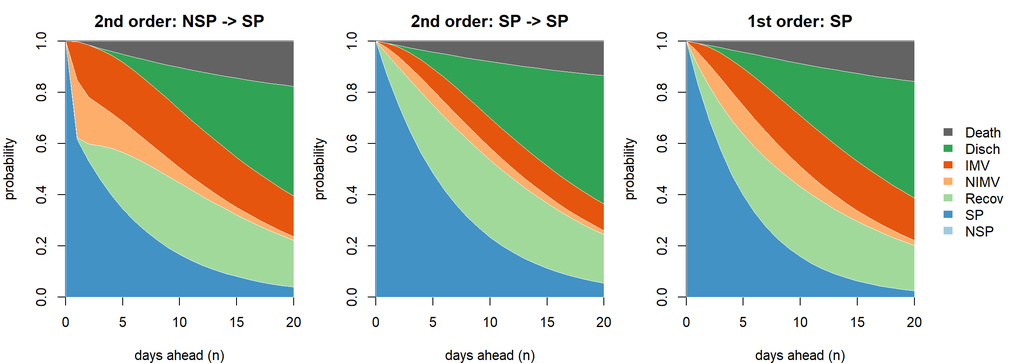

Patient A goes through ventilation much more often during the first week than patient B; the first-order prediction (`T1`: every slice of the tensor equal to the first-order matrix) differs from both.

## `compare2()` and `overlap_step()`: for how long does it matter?

compare2(object, h, j, l, nsteps = 9, bounds = TRUE) · overlap_step(x)

```r
cmp_nimv <- compare2(fit, h = c("NSP", "SP"), j = "SP", l = "NIMV")
cmp_imv  <- compare2(fit, h = c("NSP", "SP"), j = "SP", l = "IMV")
op <- par(mfrow = c(1, 2))
plot(cmp_nimv, dualaxis = FALSE, xlab = "steps (n)", main = "SP -> NIMV")
plot(cmp_imv,  dualaxis = FALSE, xlab = "steps (n)", main = "SP -> IMV")
```

```r
par(op)
```

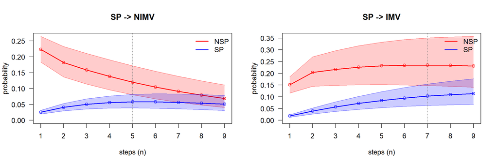

With the evolution intervals, the curves first overlap after **5 days** for `NIMV` and **7 days** for `IMV` (dotted line): the memory of the previous state lasts about a week.

## `overlap_step()` in detail

```r
overlap_step(cmp_nimv)[c("n", "s", "separated_steps", "separation")]
```

```
#> $n
#> [1] 5
#>
#> $s
#> [1] 6
#>
#> $separated_steps
#> [1] 4
#>
#> $separation
#>         1         2         3         4         5         6         7         8         9
#>  0.152080  0.083878  0.047085  0.019393 -0.001119 -0.015992 -0.026462 -0.033517 -0.037944
```

```r
summary(cmp_imv)
```

```
#> Trajectory comparison (RPE, 95% evolution intervals)
#>   target 'IMV' via current state 'SP'; preceding: NSP, SP
#>   intervals first overlap at step 7 (time s = 8); significant for the first 6 step(s).
```

**What it returns**: `n`, the first step at which the intervals overlap, and `s = n + 1`, the corresponding time; `separated_steps`; and `separation` $= \max(L_1, L_2) - \min(U_1, U_2)$ at each step, positive while the intervals are apart.

## Bootstrap intervals

Only the input changes: `bt` (from `P2boot()`) instead of `fit`.

| `SP` → `NIMV` | Evolution (`fit`) | Bootstrap (`bt`) |
| --- | --- | --- |
| Days with intervals apart | 4 | **7** |
| First overlap | step 5 | **step 8** |
| Interval for A at step 5 | 0.080–0.172 | **0.099–0.141** |

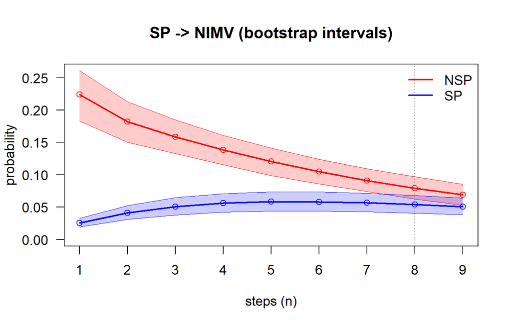

```r
cmp_b <- compare2(bt, h = c("NSP", "SP"),
                  j = "SP", l = "NIMV")
plot(cmp_b, dualaxis = FALSE, main = "SP -> NIMV")
```

**Narrower**: each bootstrap replicate is a coherent set of probabilities, so the uncertainty is propagated jointly instead of putting every probability at its limit. The conclusion holds: the previous state matters for **about a week**.

## Example: evolution vs bootstrap intervals, step by step

Patient A (yesterday `NSP`, today `SP`): probability of `NIMV` in **2 days**. Estimate: 0.016 + 0.166 = **0.182**.

**Evolution intervals** (`P2est`): the same calculation with **every** probability at its lower limit (`fit$P.lower`), then at its upper limit (`fit$P.upper`)

| path | with lower limits | with upper limits |
| --- | --- | --- |
| SP → SP → NIMV | 0.569 × 0.020 = 0.011 | 0.663 × 0.031 = 0.021 |
| SP → NIMV → NIMV | 0.184 × 0.684 = 0.126 | 0.264 × 0.802 = 0.212 |
| **Total** | **0.137** | **0.233** |

The limit tensors are not probabilities: row (`NSP`, `SP`) sums to 0.868 in `P.lower` and 1.135 in `P.upper`.

**Bootstrap intervals** (`P2boot`): the same calculation in **each** of the 500 resampled tensors, then the percentiles

| replicate | day 1 | day 2 |
| --- | --- | --- |
| 1 | 0.219 | 0.176 |
| 2 | 0.221 | 0.182 |
| 3 | 0.207 | 0.169 |
| … | … | … |
| 500 | 0.205 | 0.165 |
| **2.5% – 97.5%** | **0.183 – 0.261** | **0.150 – 0.213** |

Each replicate is a valid tensor (rows sum to 1), so errors partly cancel.

Day 2: evolution **0.137 – 0.233** vs bootstrap **0.150 – 0.213**. Day 5: evolution **0.080 – 0.172** vs bootstrap **0.099 – 0.141**: every step adds the extreme combination of limits, so evolution intervals widen faster.

## Summary

| Question | Function |
| --- | --- |
| How do I get a daily panel from my data (including `mstate` data)? | `msprep2()`, `rnd()` |
| What are the second-order counts? | `prep2()`, `summary()` |
| What is $P_{hj\ell}$, with its uncertainty? | `P2est()`, `P2boot()` |
| Where will a patient be in $n$ days? | `ckequations()` |
| Does the previous state matter, and for how long? | `compare2()`, `overlap_step()` |

## References

- Anderson, T. W. and Goodman, L. A. (1957). Statistical inference about Markov chains. *The Annals of Mathematical Statistics*, 28(1), 89–110.
- Besalú, M. and Gómez Melis, G. (2024). Second order Markov multistate models. *SORT*, 48(2), 209–234.
- Davison, A. C. and Hinkley, D. V. (1997). *Bootstrap Methods and their Application*. Cambridge University Press.
- de Wreede, L. C., Fiocco, M. and Putter, H. (2011). mstate: an R package for the analysis of competing risks and multi-state models. *Journal of Statistical Software*, 38(7), 1–30.
- Efron, B. and Tibshirani, R. J. (1993). *An Introduction to the Bootstrap*. Chapman and Hall.
- Najera-Zuloaga, J., Besalú, M. and Gómez Melis, G. (2025). Second-order Markov multistate models: nonparametric estimation and inference. Manuscript submitted for publication.
- Putter, H., Fiocco, M. and Geskus, R. B. (2007). Tutorial in biostatistics: competing risks and multi-state models. *Statistics in Medicine*, 26(11), 2389–2430.